Raw data:

| Chromosome | Start | End | Color | invCenters | NHCenters | NAHRCenters | Length.Mb | allRepCounts | WAvgRate.perMb | ChromType |
| --- | --- | --- | --- | --- | --- | --- | --- | --- | --- | --- |
| chr10 | 158946 | 16728068 | telomeric | 3 | 2 | 1 | 16.569122 | 272 | 2.0834355 | A |
| chr10 | 33436031 | 39097912 | centromeric | 1 | 0 | 1 | 5.661881 | 556 | 1.4181419 | A |
| chr10 | 113381279 | 135473442 | telomeric | 1 | 1 | 0 | 22.092163 | 170 | 2.1846155 | A |
| chr10 | 42436301 | 58578148 | centromeric | 1 | 1 | 0 | 16.141847 | 1672 | 0.9909238 | A |
| chr11 | 241489 | 23608385 | telomeric | 1 | 0 | 1 | 23.366896 | 720 | 1.7638010 | A |
| chr11 | 43687013 | 51394932 | centromeric | 0 | 0 | 0 | 7.707919 | 494 | 1.0575223 | A |

For each window, I calculated the number of total inversions, NH inversions, and NAHR inversions, the window length in Mb, number of repeats and the average recombination rate in cM/Mb.

I want to perform Ordinal Logistic Regressions on different subsets of the data. The assumptions of the Ordinal Logistic Regression are as follow:

1. The dependent variable is ordered.
2. One or more of the independent variables are either continuous, categorical or ordinal.
3. No multi-collinearity.
4. Proportional odds.

I show the data distributions in the figure below. The inversion counts have only a number of possible options, so they can be considered an ordinal variable. The independent variables are continuous and categorical, so assumptions 1 and 2 are satisfied

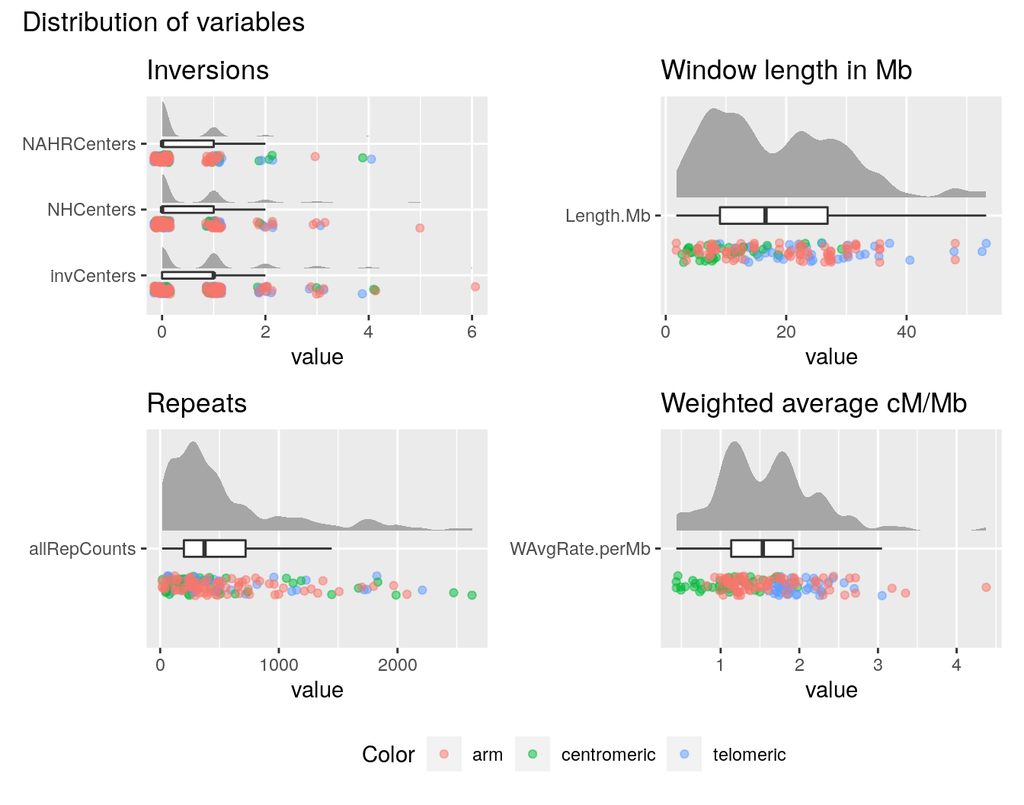

Distribution of variables.

We see that some categories have low number of cases, so I will make a “3 or more” category when relevant.

Original counts

| CountGroups | invCenters | NHCenters | NAHRCenters |
| --- | --- | --- | --- |
| 0 | 72 | 97 | 114 |
| 1 | 52 | 41 | 31 |
| 2 | 16 | 10 | 5 |
| 3 | 8 | 4 | 1 |
| 4 | 4 | NA | 2 |
| 5 | NA | 1 | NA |
| 6 | 1 | NA | NA |

New counts

|  | CountGroups | invCategory | NHCategory | NAHRCategory |
| --- | --- | --- | --- | --- |
| 1 | Absence | 72 | 97 | 114 |
| 3 | Presence | 68 | 51 | 36 |
| 2 | Abundance | 13 | 5 | 3 |

With these groups, I visualize the relationships between dependent and independent variables.

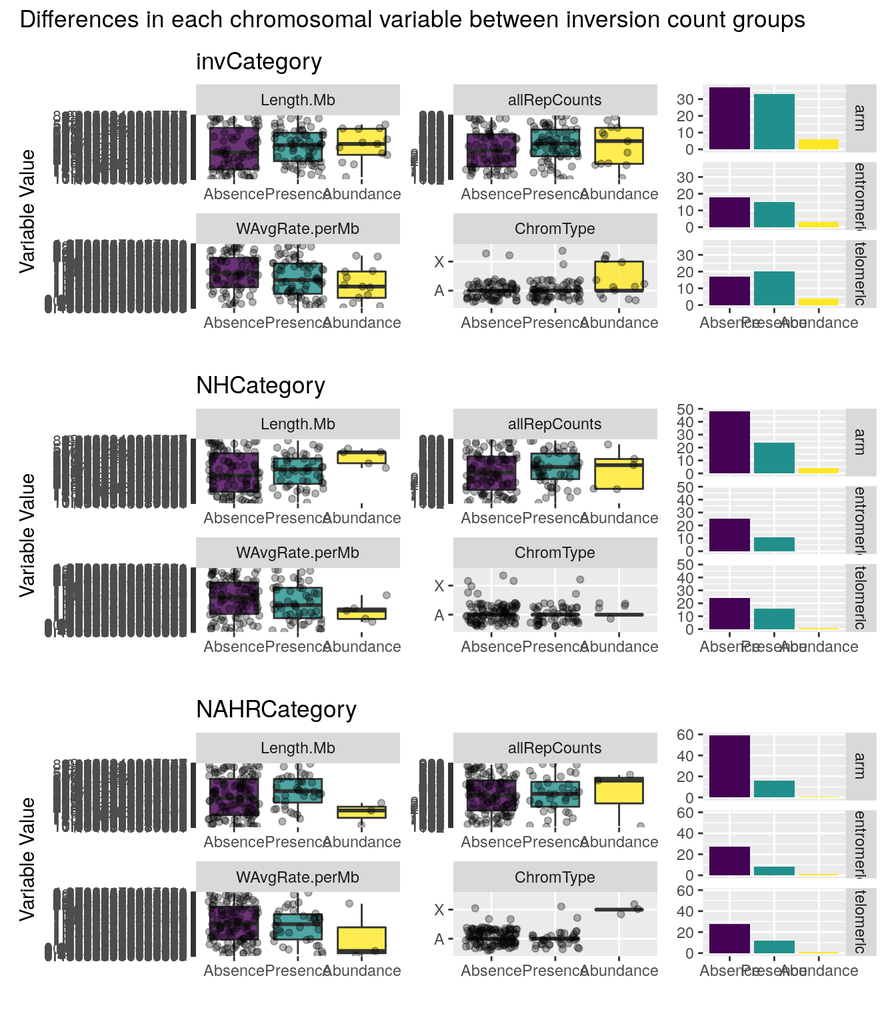

Potential effect of independent variables on the different types of invesions.

Finally, I will test assumption number 3, no multi-collinearity between independent variables.

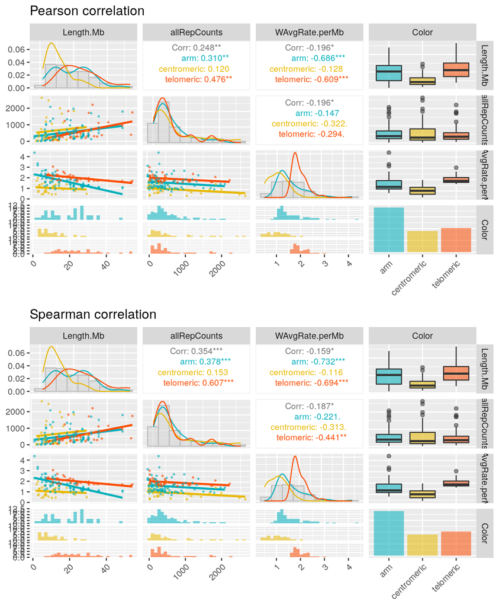

Correlations between variables.

We see that our three variables are significantly correlated, but this does not confirm multi-collinearity. I perform a variance inflation factor test on the corresponging linear model to further check the multi-collinearity.

|  | GVIF | Df | GVIF^(1/(2*Df)) |
| --- | --- | --- | --- |
| Length.Mb | 1.931714 | 1 | 1.389861 |
| allRepCounts | 1.105951 | 1 | 1.051642 |
| Color | 2.573944 | 2 | 1.266630 |
| WAvgRate.perMb | 2.163202 | 1 | 1.470783 |

The general rule of thumbs for VIF test is that if the VIF value is greater than 10, then there is multi-collinearity, so we can say that the third assumption (no multi-collinearity) is satisfied.

The proportional odds assumption will be tested for each model that we fit in the following analyses.

## Variable scalation (optional)

Standardized coefficients are useful in our case to compare effects of predictors reported in different units. The most straightforward way is using the Agresti method of standardization, applied with the `scale()` function.

|  | Length.Mb | Length.Mb.Scaled | allRepCounts | allRepCounts.Scaled | WAvgRate.perMb | WAvgRate.perMb.Scaled |
| --- | --- | --- | --- | --- | --- | --- |
| Min. | 1.741944 | -1.4979278 | 16.0000 | -0.9932976 | 0.4356883 | -1.8539902 |
| 1st Qu. | 8.999548 | -0.8481517 | 200.0000 | -0.6589042 | 1.1341848 | -0.7230993 |
| Median | 16.569122 | -0.1704450 | 374.0000 | -0.3426843 | 1.5359258 | -0.0726664 |
| Mean | 18.472889 | 0.0000000 | 562.5621 | 0.0000000 | 1.5808082 | 0.0000000 |
| 3rd Qu. | 26.886669 | 0.7532889 | 720.0000 | 0.2861206 | 1.9196997 | 0.5486773 |
| Max. | 53.232426 | 3.1120343 | 2628.0000 | 3.7536347 | 4.3762818 | 4.5259719 |

Once the model is fitted, we can use the sd to transform scaled coefficients to natural coefficients and viceversa.